# 8b: Forecasting GARCH

[Nao Mimoto](https://nmimoto.github.io/) - [Dept. of Statistics](http://www.uakron.edu/stat/) : [The University of Akron](http://www.uakron.edu) [– Class Web Page](https://nmimoto.github.io/477/)

## 1. GARCH model

GARCH(1,1) model
$$\begin{align*}
Y_t &= \sigma_t \epsilon_t \hspace{10mm} \epsilon_t \sim_{iid}
N(0,1) \\\\
\sigma_t^2 &= \omega + \alpha Y_{t-1}^2 + \beta \sigma^2_{t-1}
\end{align*}$$

#### Conditional Mean and Var of GARCH

Conditional Mean: $0$

Conditional Variance : $\sigma_t^2$

#### Mean and Var of GARCH

(unconditional) Mean: $0$

(unconditional) Variance : $\sigma_t^2$

### 1a. Ex: Daily SPY

Live donload Daily Price of SP500 ETF (SPY) from Yahoo!

```r
  library(quantmod)
  source('https://nmimoto.github.io/R/TS-00.txt')

  getSymbols("SPY")    #- Download SP500 now from Yahoo!
```

```
## [1] "SPY"
```

```r
  SPY = Ad(SPY)['2010::']

  is.ts(SPY)      # not ts object
```

```
## [1] FALSE
```

```r
  is.xts(SPY)     # its xts object
```

```
## [1] TRUE
```

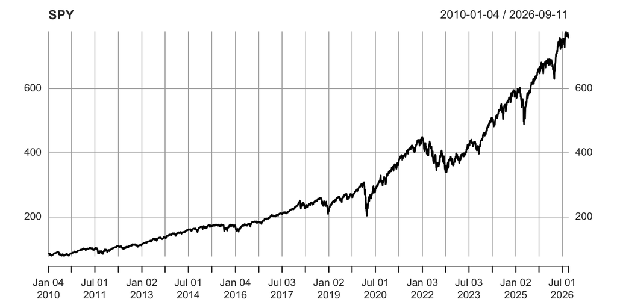

```r
  plot( SPY )
```

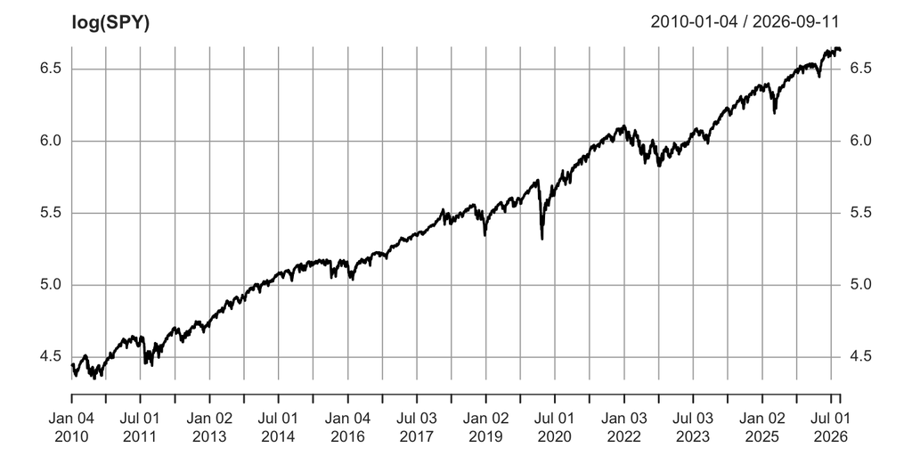

```r
  plot( log(SPY) )
```

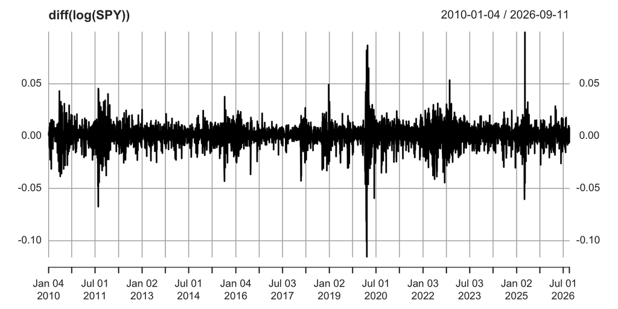

```r
  plot( diff( log(SPY) ) )
```

### 1b. Fit GARCH(1,1)

```r
  library(fGarch)   # for garchFit()

  Y = diff( log(SPY) )[-1]     # remove the first diff for NA

    Fit01 =  garchFit(~ garch(1,1), data=Y, cond.dist="norm", include.mean = FALSE, trace = FALSE)
    Fit01
```

```
##
## Title:
##  GARCH Modelling
##
## Call:
##  garchFit(formula = ~garch(1, 1), data = Y, cond.dist = "norm",
##     include.mean = FALSE, trace = FALSE)
##
## Mean and Variance Equation:
##  data ~ garch(1, 1)
## <environment: 0x11aa29b80>
##  [data = Y]
##
## Conditional Distribution:
##  norm
##
## Coefficient(s):
##      omega      alpha1       beta1
## 3.7798e-06  1.5098e-01  8.1387e-01
##
## Std. Errors:
##  based on Hessian
##
## Error Analysis:
##         Estimate  Std. Error  t value Pr(>|t|)
## omega  3.780e-06   4.755e-07    7.949 1.78e-15 ***
## alpha1 1.510e-01   1.290e-02   11.703  < 2e-16 ***
## beta1  8.139e-01   1.396e-02   58.291  < 2e-16 ***
## ---
## Signif. codes:  0 '***' 0.001 '**' 0.01 '*' 0.05 '.' 0.1 ' ' 1
##
## Log Likelihood:
##  13917.88    normalized:  3.31615
##
## Description:
##  Sun Sep 13 15:21:21 2026 by user:
```

```r
    ##  Fit01@fit$par                  # estimated parameters
    ##  Fit01@residuals                # this is not GARCH residuals! This is same as Y.
    ##  Fit01@sigma.t                  # estimated sig_t
    ##  Fit01@fit$ics                   # AIC and BIC are here
    ##  Fit01@residuals/Fit1@sigma.t   # this is the (standardized) GARCH residuals

    Fit01@fit$ics                   # AIC and BIC are here
```

```
##       AIC       BIC       SIC      HQIC
## -6.630870 -6.626336 -6.630871 -6.629267
```

```r
    res1  = Y/Fit01@sigma.t        #- this is GARCH residuals
```

### 1c. plotting resutls

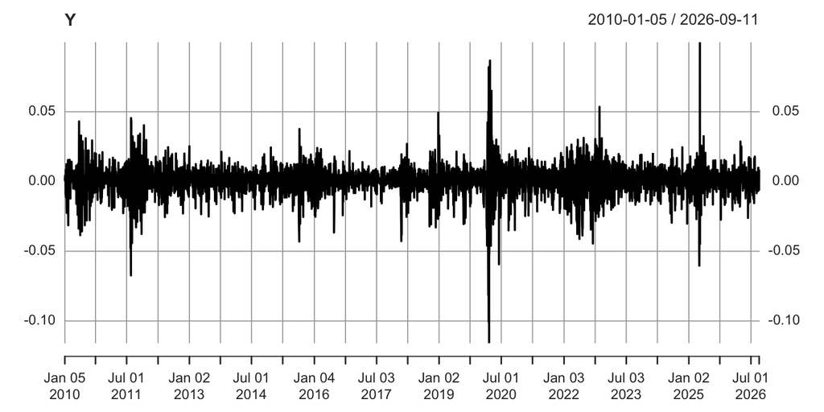

```r
    plot(Y) # log difference
```

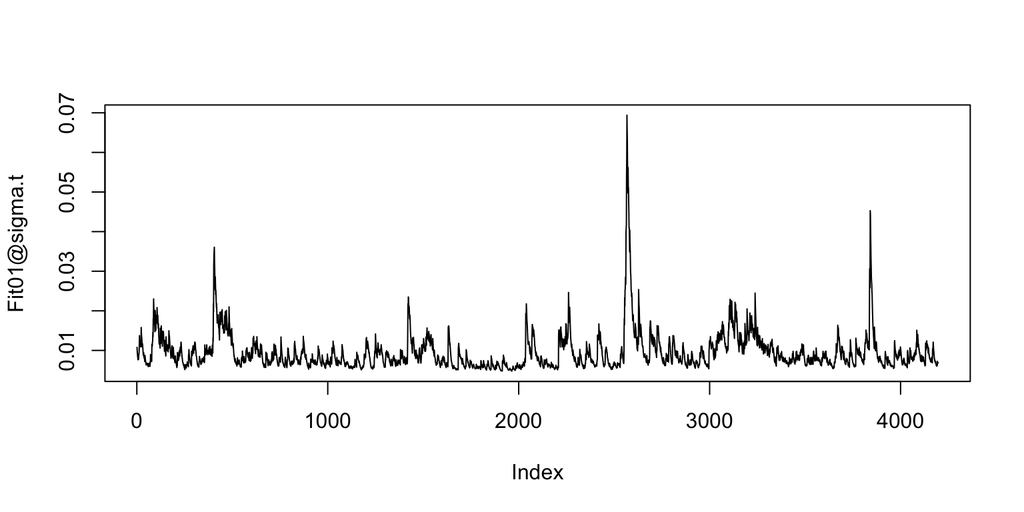

```r
    plot(Fit01@sigma.t, type="l")   # estimated Sigma_t
```

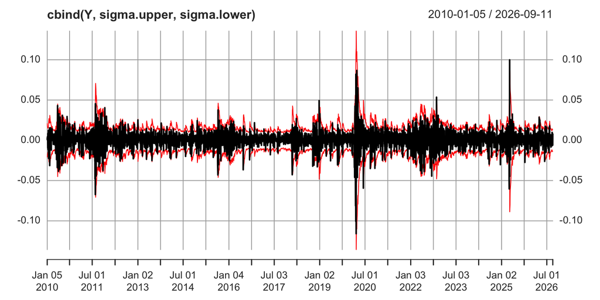

```r
    sigma.upper = xts(1.96*Fit01@sigma.t,  order.by=index(Y))
    sigma.lower = xts(-1.96*Fit01@sigma.t, order.by=index(Y))

    # Plot the two together
    plot( cbind(Y, sigma.upper, sigma.lower),
        col=c("black", "red", "red"), lwd=c(2,1,1) )
```

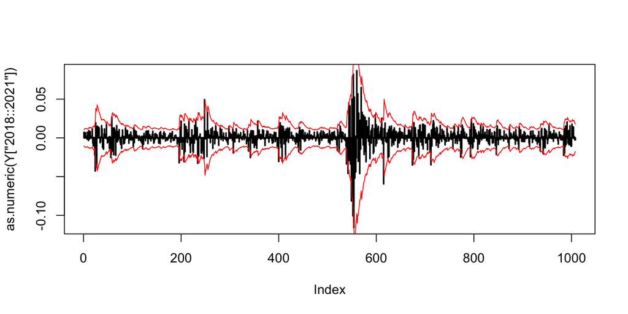

```r
    # Zoom in
    plot(  as.numeric(          Y["2018::2021"]), type="h", lwd=2)
    lines( as.numeric(sigma.upper["2018::2021"]), col="red")
    lines( as.numeric(sigma.lower["2018::2021"]), col="red")
```

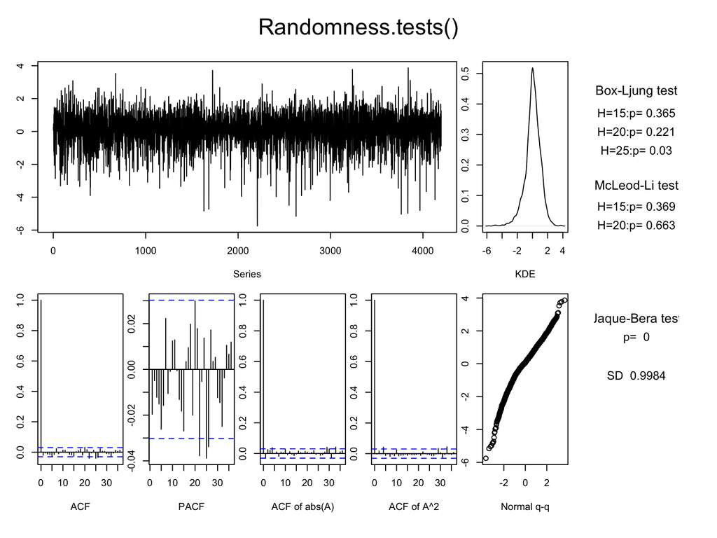

```
##   B-L test H0: the series is uncorrelated
##   M-L test H0: the square of the series is uncorrelated
##   J-B test H0: the series came from Normal distribution
##   SD         : Standard Deviation of the series
```

```
##       BL15  BL20 BL25  ML15  ML20 JB    SD
## [1,] 0.365 0.221 0.03 0.369 0.663  0 0.998
```

```r
# Test standardized log difference for randomness
Randomness.tests(res1)
```

## 2. Parameter Estimation

### 2a. Quasi-MLE

Quasi-Maximum Likelihood Estimator, means we will use MLE for normal errors, even in the case of non-normality. Theoretically, for GARCH parameters, it is shown that Normal MLE is still consistent under non-normal errors.

GARCH(1,1)

$$\begin{align*}
Y_t &= \sigma_t \epsilon_t \hspace{10mm} \epsilon_t \sim_{iid}
N(0,1)\\\\
\sigma_t^2 &= \omega + \alpha Y_{t-1}^2 + \beta \sigma^2_{t-1}
\end{align*}$$

Even thorugh we can use quasi-MLE based on Normal distribution, using correct conditional distribution is importatnt when estimating parameters of GARCH.

### 2b. Importatnce of Conditional Distribution

$$\begin{align*}
Y_t &= \sigma_t \epsilon_t \hspace{10mm} \epsilon_t \sim_{iid}
N(0,1)\\\\
\sigma_t^2 &= \omega + \alpha Y_{t-1}^2 + \beta \sigma^2_{t-1}
\end{align*}$$

[Conditonal distribution] $=$ [Distribution of $\epsilon_t$]

Guessing correct distribution for $\epsilon_t$ is very important in GARCH parameter estimation.

### 2c. Four Built-in distributions

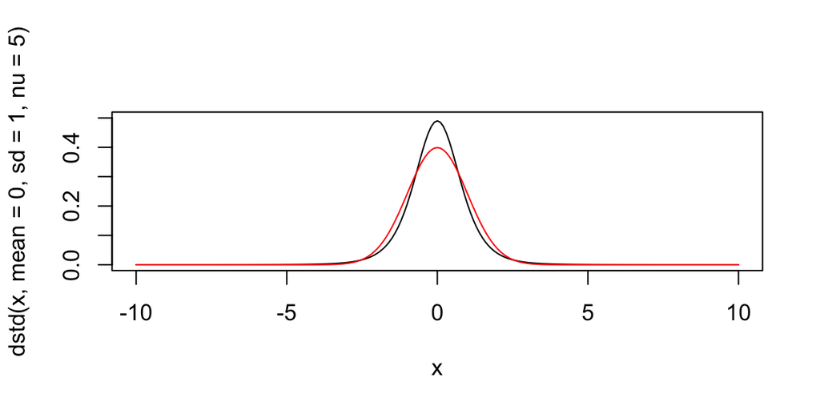

```r
  x = seq(-10,10, .1)

  #- Standardized t-distribution
  plot(x, dstd(x, mean = 0, sd = 1, nu = 5), type="l", ylim=c(0,.5))
  lines(x, dnorm(x, mean = 0, sd = 1), col="red" )
```

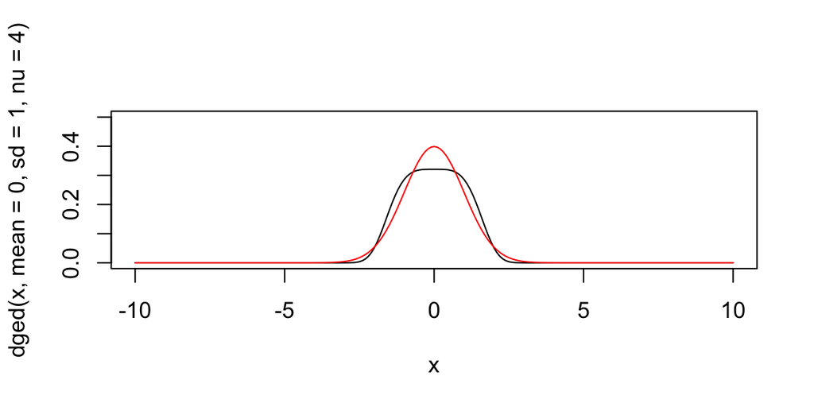

```r
  #- Generalized Error Distribution
  plot(x, dged(x, mean = 0, sd = 1, nu = 4), type="l", ylim=c(0,.5))
  lines(x, dnorm(x, mean = 0, sd=1) , col="red" )
```

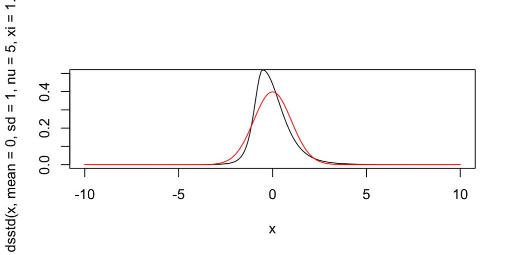

```r
  #- Skewed-Standardized t-distribution
  plot( x, dsstd(x, mean = 0, sd = 1, nu = 5, xi = 1.5), type="l", ylim=c(0,.5))
  lines(x, dnorm(x, mean = 0, sd = 1), col="red" )
```

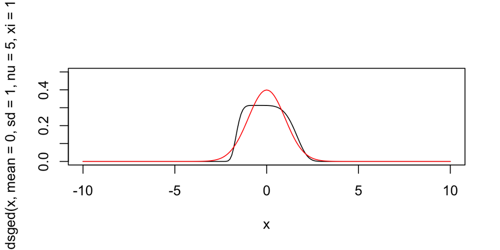

```r
  #- Skewed-Generalized Error Distribution
  plot(x, dsged(x, mean = 0, sd = 1, nu = 5, xi = 1.5) , type="l", ylim=c(0,.5))
  lines(x, dnorm(x, mean = 0, sd = 1), col="red" )
```

### 2d. Simulation Demo of Parameter Estimation Efficiency

True parameter (.024, .1, .8)

True conditional distribution is Normal. Estimated using Normal.

True conditional distribution is std(5), but estimated using Normal.

```r
  # Simulation showing how error distribution affect parameter estimation in GARCH(1,1) ---
  # (Takes about 3min)
  n   = 1000
  itt = 1000
  theta = c(.024, .1, .8)

  set.seed(62192)  #36621)
  Param11 = matrix(rep(0,3*itt), itt, 3)
  for (i in 1:itt) {

    spec = garchSpec(model = list(omega=theta[1], alpha=theta[2], beta=theta[3]),
                                                               cond.dist="norm")
    x    = garchSim(spec, n = n, extended=FALSE)

    est2 =  garchFit(~ garch(1,1), data=x, cond.dist="norm",  include.mean = FALSE, trace = FALSE)
    Param11[i,] = coef(est2)
  }

  Param12 = matrix(rep(0,3*itt), itt, 3)
  for (i in 1:itt) {

    spec = garchSpec(model = list(shape=5, omega=theta[1], alpha=theta[2], beta=theta[3]),
                                                                cond.dist="std")
    x     = garchSim(spec, n = n, extended=FALSE)

    est2 =  garchFit(~ garch(1,1), data=x, cond.dist="norm",  include.mean = FALSE, trace = FALSE)
    Param12[i,] = coef(est2)
  }

  Param13 = matrix(rep(0,3*itt), itt, 3)
  for (i in 1:itt) {

    spec = garchSpec(model = list(skew=.9,  shape=1.45, omega=theta[1], alpha=theta[2], beta=theta[3]),
                                                                cond.dist="sged")
    x    = garchSim(spec, n = n, extended=FALSE)

    est2 =  garchFit(~ garch(1,1), data=x, cond.dist="norm",  include.mean = FALSE, trace = FALSE)
    Param13[i,] = coef(est2)
  }
```

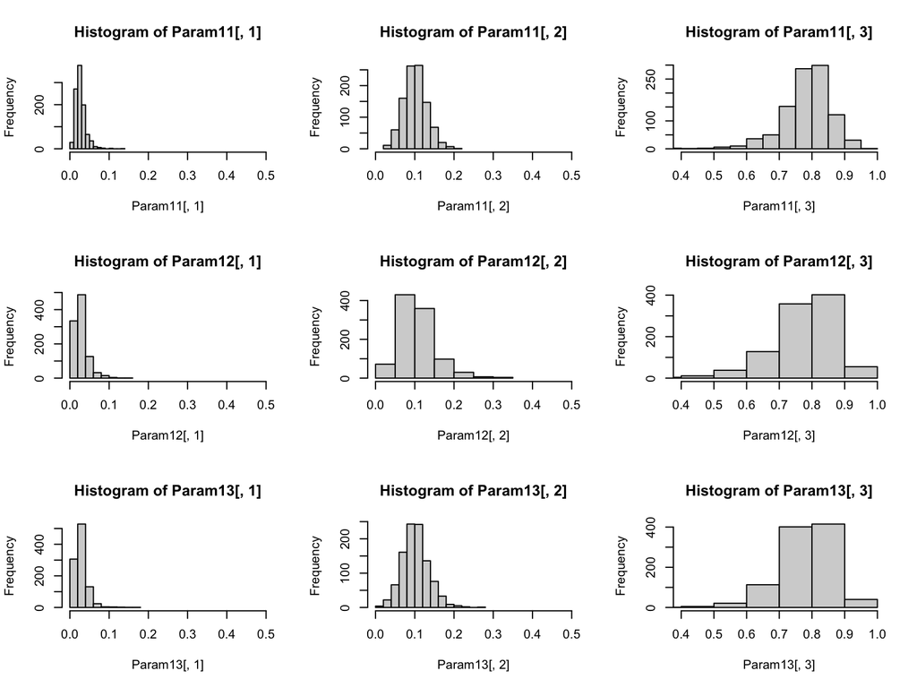

```r
  layout(matrix(1:9, 3, 3, byrow=T))
  hist(Param11[,1], 10, xlim=c(0,.5)); hist(Param11[,2], 10, xlim=c(0,.5));
    hist(Param11[,3], xlim=c(0.4,1), breaks=10)
  hist(Param12[,1], 10, xlim=c(0,.5)); hist(Param12[,2], 10, xlim=c(0,.5));
    hist(Param12[,3], xlim=c(0.4,1), breaks=10)
  hist(Param13[,1], 10, xlim=c(0,.5)); hist(Param13[,2], 10, xlim=c(0,.5));
    hist(Param13[,3], xlim=c(0.4,1), breaks=10)
```

```r
  P11 = (Param11 - t(matrix(theta, 3, itt) ))^2
  P12 = (Param12 - t(matrix(theta, 3, itt) ))^2
  P13 = (Param13 - t(matrix(theta, 3, itt) ))^2

  # Raw MSE
  MSE1 = apply(P11, 2, mean)
  MSE2 = apply(P12, 2, mean)
  MSE3 = apply(P13, 2, mean)

  # Relative MSE
  rbind(MSE1 / MSE1,
        MSE2 / MSE1,
        MSE3 / MSE1)
```

```
##          [,1]     [,2]     [,3]
## [1,] 1.000000 1.000000 1.000000
## [2,] 1.770278 2.513438 1.858293
## [3,] 1.490498 1.324999 1.431167
```

## 3. Stationarity Cond’n for GARCH(1,1)

GARCH(1,1) is weakly stationary if
$$E( \log(\beta + \alpha \epsilon_t^2)) < 0.$$

This is satisfied if
$$\alpha + \beta < 1.$$

## 4. Predicting $\sigma_t$

### 4a. Residuals of GARCH

GARCH(1,1)
$$\begin{align*}
Y_t &= \sigma_t \epsilon_t \hspace{10mm} \epsilon_t \sim_{iid}
N(0,1)\\\\
\sigma_t^2 &= \omega + \alpha Y_{t-1}^2 + \beta \sigma^2_{t-1}
\end{align*}$$

Using observation $\{Y_1, \ldots, Y_n\}$, the residuals are
$$\hat \epsilon_t = Y_t/ \hat \sigma_t$$

how can we get $\hat \sigma_t$?

### 4b. Write $\sigma^2_t$ using $Y_t^2$

Starting with the definition of GARCH(1,1),

$$\begin{align*}
\sigma_t^2 &= \omega + \alpha Y_{t-1}^2 + \beta
\sigma^2_{t-1} \\\\
&= \omega + \alpha Y_{t-1}^2 + \beta \Big(\omega + \alpha
Y_{t-2}^2 + \beta \sigma^2_{t-2} \Big)\\ \\
&= \omega + \beta \omega + \alpha Y_{t-1}^2 + \beta \alpha
Y_{t-2}^2 + \beta^2 \sigma^2_{t-2} \\ \\
&= \omega + \beta \omega + \alpha Y_{t-1}^2 + \beta \alpha
Y_{t-2}^2 + \beta^2 \Big(\omega + \alpha Y_{t-3}^2 + \beta
\sigma^2_{t-3} \Big) \\ \\
&= \omega + \beta \omega + \beta^2 \omega + \alpha Y_{t-1}^2 +
\beta \alpha Y_{t-2}^2 + \beta^2 \alpha Y_{t-3}^2 + \beta^3
\sigma^2_{t-3}
\end{align*}$$

Continuing, we get
$$\begin{align*}
&= \omega (1 + \beta + \beta^2 + \cdots )
+ \alpha \sum_{i=0}^k \beta^i Y_{t-1-i}^2 + \beta^{k+1}
\sigma^2_{t-1-k} \\\\
&= \frac{\omega}{1-\beta} + \alpha \sum_{i=0}^\infty \beta^i
Y_{t-1-i}^2
\end{align*}$$

That means if we keep going, we can write
$$\sigma_t^2 \hspace{3mm} = \hspace{3mm}
\frac{\omega}{1-\beta} + \alpha \sum_{i=0}^\infty \beta^i
Y_{t-1-i}^2$$

We will use the truncated and estimated version of this,
$$\hat \sigma_t^2 \hspace{3mm} = \hspace{3mm}
\frac{\hat \omega}{1- \hat \beta}
\hspace{3mm} + \hspace{3mm} \hat \alpha \sum_{i=0}^{t-1} \hat
\beta^i Y_{t-1-i}^2$$

### 4c. Now We Can Calculate Residuals

GARCH(1,1) says,
$$Y_t \hspace{3mm} = \hspace{3mm} \sigma_t \epsilon_t$$

Using observation $\{Y_1, \ldots, Y_n\}$, the residuals are
$$\hat \epsilon_t = Y_t/ \hat \sigma_t$$

### 4d. Forecast $\sigma_{t+1}$

GARCH(1,1)
$$\begin{align*}
Y_t &= \sigma_t \epsilon_t \hspace{10mm} \epsilon_t \sim_{iid}
N(0,1)\\\\
\sigma_t^2 &= \omega + \alpha Y_{t-1}^2 + \beta \sigma^2_{t-1}
\end{align*}$$

Now have 1-step forecast of tomorrow’s volatility $\sigma_{t+1}$,
$$\begin{align*}
\sigma_{t}^2(1) &= \hat \omega + \hat \alpha Y_{t}^2 + \hat
\beta \hat \sigma^2_{t}
\end{align*}$$

How well can GARCH predict $\sigma_t$ of the future?